# Plotting Population Genomic results in `R`

Curro Campuzano

## Plotting Population Genomic results in R

by the Svardal lab, based on material by Alexandros Bantounas and contributions by Curro Campuzano <sup>1</sup>.

## Overview of the data

In order to plot the genomics results, certain output files need to be downloaded to the local drive and in our working/project directory. Download the following files:

- The .dist and .dist.id files for the distance matrix.
- The metadata .csv file.
- The .eigenvec and .eigenval files for the PCA.
- The .fam and .Q files for the ADMIXTURE analysis.
- The windowed.weir.fst file for the Fst analysis.

## Metadata

First step, is to load the metadata:

```
# A tibble: 20 × 7
   Sample_ID Population Full_Pop        Clade       Sex    Latitude Longitude
   <chr>     <chr>      <chr>           <chr>       <chr>     <dbl>     <dbl>
 1 HC_21_002 ZOO        Zooridge        Cedarberg   male      -32.8      19.5
 2 HC_21_007 ZOO        Zooridge        Cedarberg   male      -32.8      19.5
 3 HC_21_010 ZOO        Zooridge        Cedarberg   female    -32.8      19.5
 4 HC_21_019 ZOO        Zooridge        Cedarberg   female    -32.8      19.5
 5 HC_21_024 WOL        Wolfberg        Cedarberg   female    -32.5      19.3
 6 HC_21_032 MAL        Maltese_Cross   Cedarberg   female    -32.5      19.2
 7 HC_21_088 GIF        Gifberg         North       male      -31.8      18.8
 8 HC_21_093 GIF        Gifberg         North       male      -31.8      18.8
 9 HC_21_095 GIF        Gifberg         North       female    -31.8      18.8
10 HC_21_103 GIF        Gifberg         North       female    -31.8      18.8
11 HC_22_025 PAP        Papkuilsfontein North       female    -31.6      19.1
12 HC_22_040 KAM        Kammanassie     East        male      -33.6      22.9
13 HC_22_049 SWE        Swellendam      East        female    -34.0      20.5
14 HC_22_054 JNK        Jonkershoek     South       male      -34.0      18.9
15 HC_22_126 SCH        Schoongezicht   Cedarberg   female    -32.8      19.2
16 HC_22_130 OUT        Ou Tol          East        female    -33.4      22.0
17 HC_22_132 ROB        Robinson_Pass   East        female    -33.9      22.0
18 HC_22_134 JON        Jonaskop        South       male      -34.0      19.5
19 HC_22_141 KOU        Kouga           East        male      -33.7      23.9
20 HC_22_225 MAT        Matroosberg     Matroosberg female    -33.4      19.7
```

## Distance matrix

First, we load the names of the samples from the `dist.id` file, and the distance matrix.

```r
dist_ids <- read_tsv("output_chr14_elisa.dist.id", col_names = c("Sample1", "Sample2"))
dist_ids$Sample1 == dist_ids$Sample2
```

```
 [1] TRUE TRUE TRUE TRUE TRUE TRUE TRUE TRUE TRUE TRUE TRUE TRUE TRUE TRUE TRUE
[16] TRUE TRUE TRUE TRUE TRUE
```

```r
distance_mat <- as.matrix(read_tsv("output_chr14_elisa.dist", col_names = F))
```

## Link samples with the metadata

```r
# We want to extract the sample id from the filename. We can achieve this
# by removing the file extension
sample_ids <- str_remove(dist_ids$Sample1, ".sorted.bam")
sample_ids
```

```
 [1] "HC_21_002" "HC_21_007" "HC_21_010" "HC_21_019" "HC_21_024" "HC_21_032"
 [7] "HC_21_088" "HC_21_093" "HC_21_095" "HC_21_103" "HC_22_025" "HC_22_040"
[13] "HC_22_049" "HC_22_054" "HC_22_126" "HC_22_130" "HC_22_132" "HC_22_134"
[19] "HC_22_141" "HC_22_225"
```

```r
# Check that the metadata is in the same order
all(metadata$Sample_ID == sample_ids)
```

```
[1] TRUE
```

```r
rownames(distance_mat) <- sample_ids
colnames(distance_mat) <- sample_ids
```

## Heaptmap

We can make a simple heatmap that shows the how samples cluster together in base `R`.

```r
heatmap(distance_mat)
```

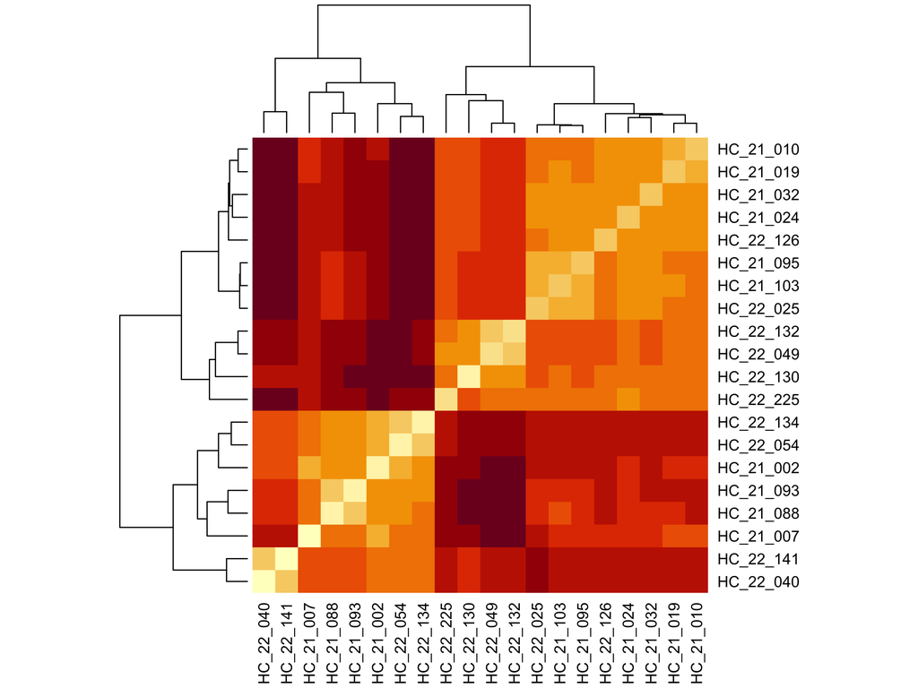

## Clustering

Notice that, in the previous plot, there is a dendrogram showing the a hierarchical structure. We can choose the agglomeration method to use.

```r
# You can execute ?heatmap and ?hclust to read the documentation
upgma <- function(x) hclust(x, method = "average")
heatmap(distance_mat, hclustfun = upgma)
```

[figure not shown]

## A more advance heatmap<sup>1</sup>

```r
# BiocManager::install("ComplexHeatmap")
library(ComplexHeatmap)
Heatmap(distance_mat, name = "Distance") +
    rowAnnotation(Clade = metadata$Clade, Sex = metadata$Sex)
```

[^2]: You can take a look at their *extensive* [documentation](https://jokergoo.github.io/ComplexHeatmap-reference/).

## A more advance heatmap

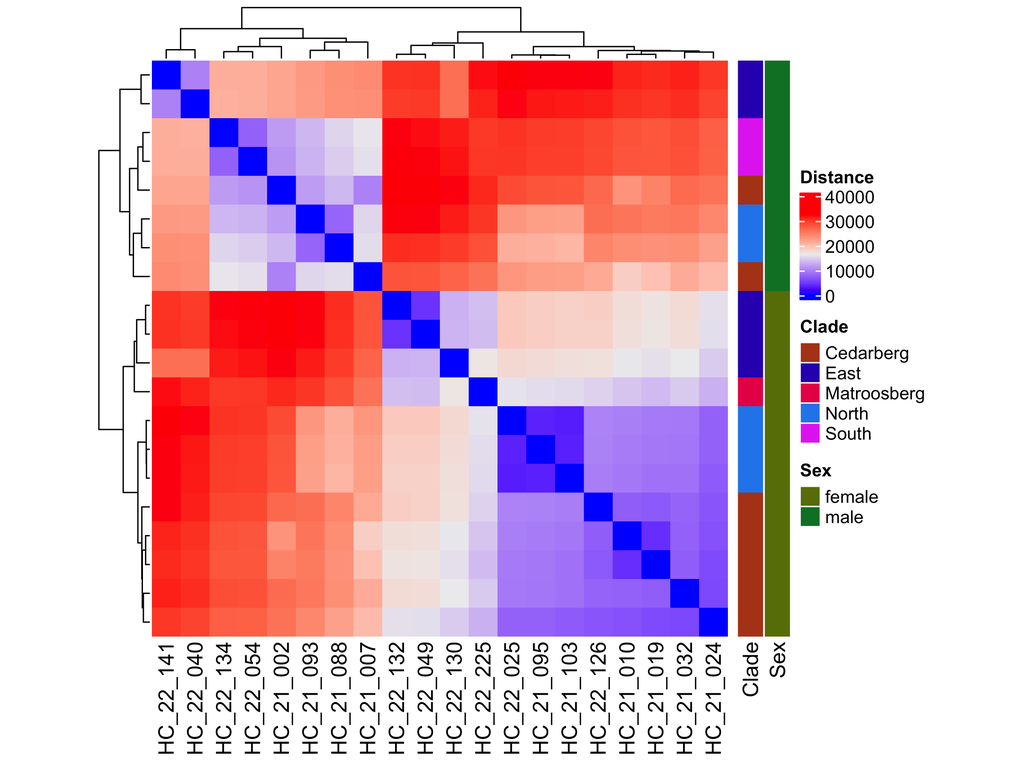

## Making and plotting a neighbour-joining (NJ) tree

Now, we will use the genomic pairwise distance matrix to create a phylogenetic tree of our samples. We can build a neighbour-joining tree using the `ape` package and visualize it using the `plot` function.<sup>1</sup>

[^3]: The `plot`function is a generic function that can be overloaded by authors of different packages.

## Making and plotting a neighbour-joining (NJ) tree

```r
# install.packages("ape")
library(ape)
nj_tree <- nj(distance_mat)
plot(nj_tree)
```

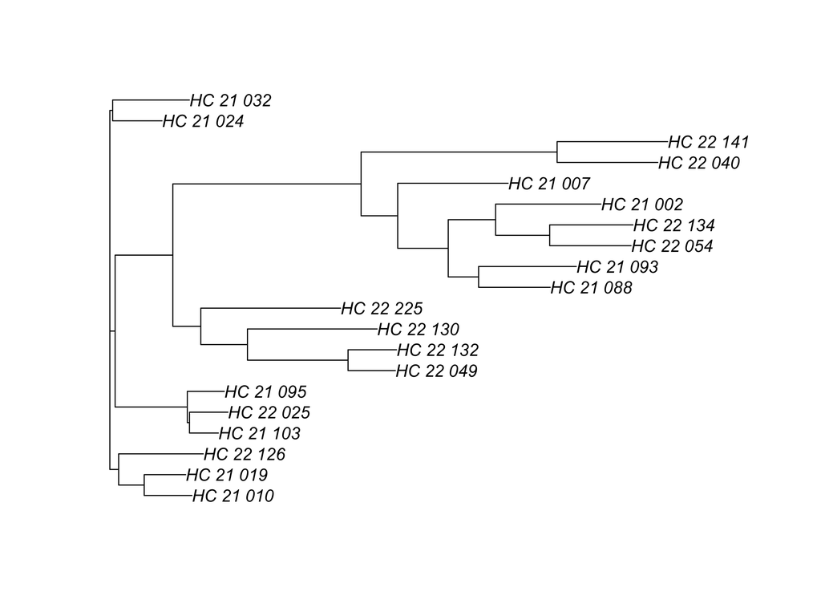

## The `ggtree` package

```r
# BiocManager::install("ggtree")
library(ggtree)
nj_tree %>%
    ggplot() +
    geom_tree() +
    geom_tiplab() +
    theme_tree()
```

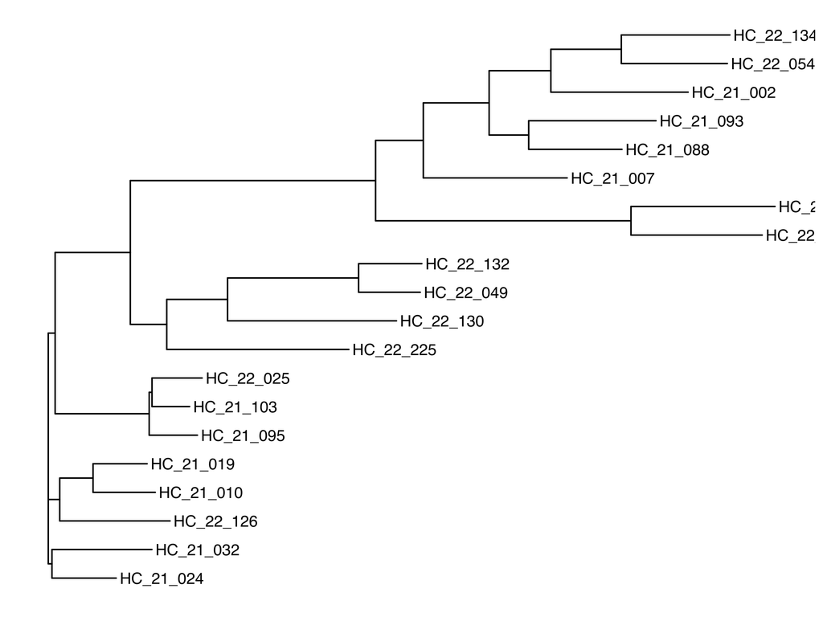